# Homework9: Organizing Code with Structured Programming

Eurydice Aboagye

2023-04-26

### Question 1

Use the code that you worked on in Homework #8 (creating fake data sets), and re-organize it following the principles of structured programming. Do all the work in a single chunk in your R markdown file, just as if you were writing a single R script. Start with all of your annotated functions, preliminary calls, and global variables. The program body should be only a few lines of code that call the appropriate functions and run them in the correct order. Make sure that the output from one function serves as the input to the next. You can either daisy-chain the functions or write separate lines of code to hold elements in temporary variables and pass them along.

```r
# Call Libraries -------------------------
library(tidyverse)
```

```r
library(ggplot2)
library(ggthemes)
# Global Variables -------------------------
z<- "BiofilmCounts.csv"
d <- read.table(z, header=TRUE,sep=",")
d <- d[complete.cases(d), ]
d <-select(d, Treatment, SanitizerType, SanitizerConc, logcfu)
isolates<-rep(c("A","B","C","D","E"),each=10)

# Functions -------------------------

######################################
# FUNCTION: tidy_data
# packages: tidyverse
# purpose:generates mean and variances of outcome variable
# input: data frame with named variables of interest
# output: a Tibble grouped according to predictor variable
# -------------------------------------
tidy_data <- function(d) {
  d_org<-d%>%
    group_by(SanitizerConc)%>%
    summarise(Average=mean(logcfu), variance=var(logcfu),n=n())
  return(as.data.frame(d_org))
    }

d_org<- tidy_data(d=d)


#######################################
# FUNCTION: sim_data
# packages: tidyverse
# purpose:Simulates random uniform dataset
# input: output of tidy_data
# output: dataframe that simulates original data set
# -------------------------------------
sim_data <- function(d){
  dframe<-data.frame(iso=isolates,
            control=rnorm(50, d_org$Average[1], d_org$variance[1]),
              low=rnorm(50, d_org$Average[2], d_org$variance[2]),
            medium=rnorm(50, d_org$Average[3], d_org$variance[3]),
            high=rnorm(50, d_org$Average[4], d_org$variance[4]))
  #created df called dframe

   x<-dframe%>%
    pivot_longer(cols= control:high, names_to = "SanitizerConc", values_to = "logcfu", values_drop_na=T)
  return(x)
  }

sim_data(d=d_org)
```

```
## # A tibble: 200 × 3
##    iso   SanitizerConc logcfu
##    <chr> <chr>          <dbl>
##  1 A     control         7.57
##  2 A     low             6.43
##  3 A     medium          5.90
##  4 A     high            3.00
##  5 A     control         8.14
##  6 A     low             4.58
##  7 A     medium          7.93
##  8 A     high            5.02
##  9 A     control         7.17
## 10 A     low             7.17
## # ℹ 190 more rows
```

```r
x<- sim_data(d=d_org)
#######################################
# FUNCTION: run_stats
# packages: tidyverse
# purpose: runs anova
# input: Output of sim_data function
# output:
# -------------------------------------
run_stats <- function(d) {
  one.way<- aov(logcfu ~ SanitizerConc, data=d)
  return(summary(one.way))

  }

run_stats(d=x)
```

```
##                Df Sum Sq Mean Sq F value  Pr(>F)
## SanitizerConc   3   34.0  11.330       5 0.00231 **
## Residuals     196  444.2   2.266
## ---
## Signif. codes:  0 '***' 0.001 '**' 0.01 '*' 0.05 '.' 0.1 ' ' 1
```

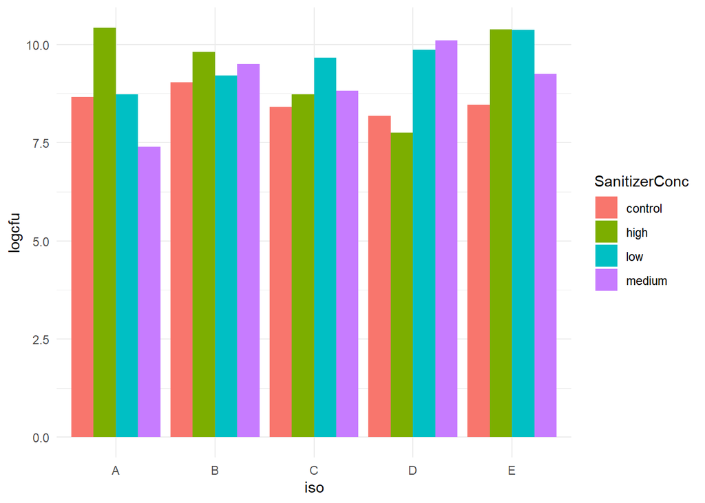

```r
#######################################
# FUNCTION: Plot_graphs
# packages: none
# purpose: plots bar graphs
# input: output of sim_data
# output: Grouped bar graphs
# -------------------------------------
Plot_graphs <- function(d) {
  graph<- ggplot(d) +
    geom_bar(aes(x = iso, y = logcfu, fill = SanitizerConc ), stat = "identity", position = "dodge") +
    theme_minimal()
  return(print(graph))

  }
Plot_graphs(d=x)
```

```r
# Program Body -------------------------

tidy_data(d=d)
```

```
##   SanitizerConc  Average  variance  n
## 1             0 7.473157 0.7157809 33
## 2            50 6.862105 1.5012014 23
## 3           100 6.914151 1.3132518 21
## 4           200 6.585848 1.9248207 23
```

```r
x<- tidy_data(d=d) # saving the output of tidy_data into a variable x

sim_data(d=x)
```

```
## # A tibble: 200 × 3
##    iso   SanitizerConc logcfu
##    <chr> <chr>          <dbl>
##  1 A     control         6.78
##  2 A     low             9.49
##  3 A     medium          6.01
##  4 A     high            7.05
##  5 A     control         7.83
##  6 A     low            10.1
##  7 A     medium          6.09
##  8 A     high            6.78
##  9 A     control         8.52
## 10 A     low             3.48
## # ℹ 190 more rows
```

```r
y<-sim_data(d=d_org) # saving the output of sim_data into a variable y

run_stats(y)
```

```
##                Df Sum Sq Mean Sq F value Pr(>F)
## SanitizerConc   3   20.8   6.941   3.585 0.0148 *
## Residuals     196  379.5   1.936
## ---
## Signif. codes:  0 '***' 0.001 '**' 0.01 '*' 0.05 '.' 0.1 ' ' 1
```

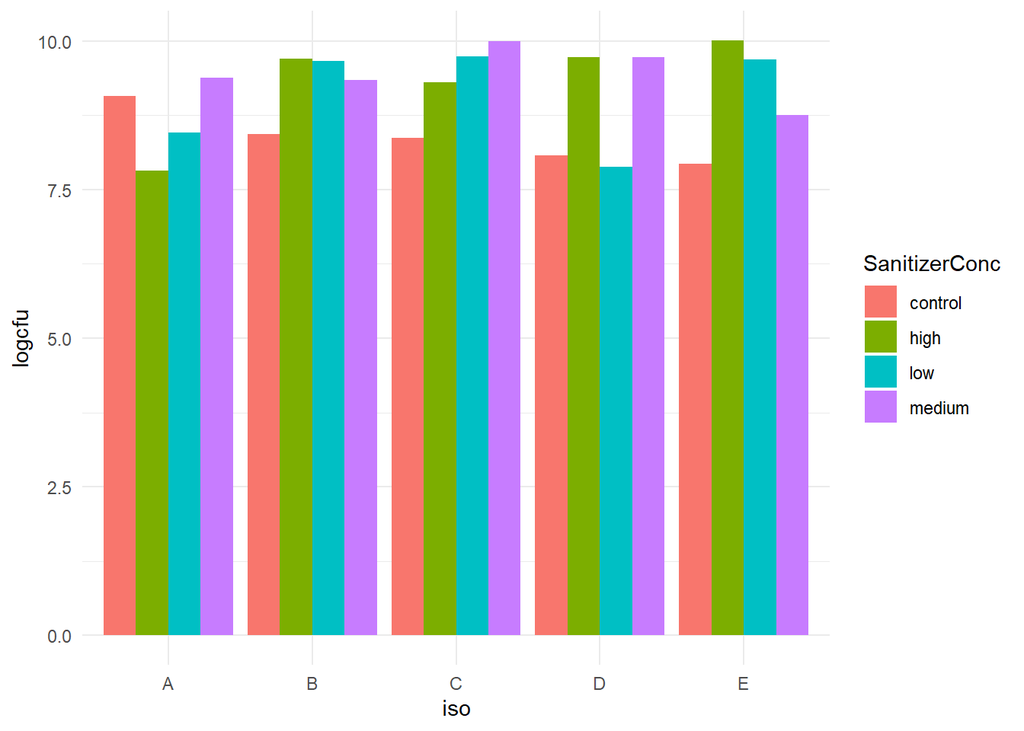

```r
Plot_graphs(y)
```

### Question Two

Once your code is up and working, modify your program to do something else: record a new summary variable, code a new statistical analysis, or create a different set of random variables or output graph. Do not rewrite any of your existing functions. Instead, copy them, rename them, and then modify them to do new things. Once your new functions are written, add some more lines of program code, calling a mixture of your previous functions and your new functions to get the job done.

```r
# FUNCTION: tidy_data
# packages: tidyverse
# purpose:generates mean and variances of outcome variable
# input: data frame with named variables of interest
# output: a Tibble grouped according to predictor variable
# -------------------------------------
tidy_data <- function(d) {
  d_org<-d%>%
    group_by(SanitizerConc)%>%
    summarise(Average=mean(logcfu), variance=var(logcfu),n=n())
  return(as.data.frame(d_org))
    }

d_org<- tidy_data(d=d)


#######################################
# FUNCTION: sim_data
# packages: tidyverse
# purpose:Simulates random uniform dataset
# input: output of tidy_data
# output: dataframe that simulates original data set
# -------------------------------------
sim_data <- function(d){
  dframe<-data.frame(iso=isolates,
            control=rnorm(100, d_org$Average[1], d_org$variance[1]),
              low=rnorm(100, d_org$Average[2], d_org$variance[2]),
            medium=rnorm(100, d_org$Average[3], d_org$variance[3]),
            high=rnorm(100, d_org$Average[4], d_org$variance[4]))
  #modified to create a larger set of random variables

   x<-dframe%>%
    pivot_longer(cols= control:high, names_to = "SanitizerConc", values_to = "logcfu", values_drop_na=T)
  return(x)
  }

sim_data(d=d_org)
```

```
## # A tibble: 400 × 3
##    iso   SanitizerConc logcfu
##    <chr> <chr>          <dbl>
##  1 A     control         6.69
##  2 A     low             9.09
##  3 A     medium          5.63
##  4 A     high            7.53
##  5 A     control         6.85
##  6 A     low             7.57
##  7 A     medium          6.42
##  8 A     high            3.35
##  9 A     control         8.22
## 10 A     low             6.98
## # ℹ 390 more rows
```

```r
x<- sim_data(d=d_org)
#######################################
# FUNCTION: run_stats
# packages: tidyverse
# purpose: runs anova
# input: Output of sim_data function
# output:
# -------------------------------------
run_stats <- function(d) {
  two.way<- aov(logcfu ~ SanitizerConc + iso, data=d)
  return(summary(two.way))

  } # modified to perform a two-way anova

run_stats(d=x)
```

```
##                Df Sum Sq Mean Sq F value   Pr(>F)
## SanitizerConc   3   40.3  13.422   6.493 0.000269 ***
## iso             4    7.9   1.972   0.954 0.432710
## Residuals     392  810.3   2.067
## ---
## Signif. codes:  0 '***' 0.001 '**' 0.01 '*' 0.05 '.' 0.1 ' ' 1
```

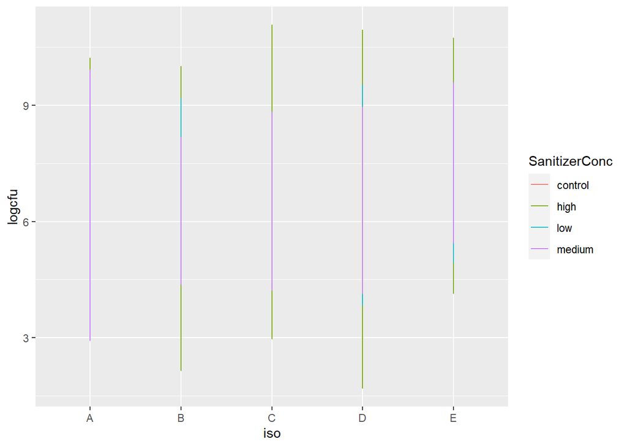

```r
#######################################
# FUNCTION: Plot_graphs
# packages: none
# purpose: plots bar graphs
# input: output of sim_data
# output: Grouped bar graphs
# -------------------------------------
Plot_graphs <- function(d) {
  graph<- ggplot(data = x, aes(x=iso, y=logcfu)) + geom_line(aes(colour=SanitizerConc))
  return(print(graph))

  } #modified to plot a line graph
Plot_graphs(d=x)
```